# Einleitung

In der heutigen Gesundheitslandschaft spielen medizinische Versicherungskosten eine entscheidende Rolle für Einzelpersonen und Familien. Das Verständnis der Faktoren, die diese Kosten beeinflussen, ist von großer Bedeutung, um fundierte Entscheidungen im Gesundheitswesen zu treffen. Das Dataset bietet eine Grundlage für die Analyse dieser Kosten, indem es eine Vielzahl von Merkmalen erfasst, darunter Alter, Geschlecht, BMI, Anzahl der Kinder, Rauchstatus und Region.

## Zielsetzung:

Durchführung einer explorativen Datenanalyse (EDA), um die Beziehungen zwischen den Merkmalen und den medizinischen Kosten zu verstehen, sowie Entwicklung von Machine-Learning-Modellen zur Vorhersage dieser Kosten.

# 1) Setup and Data Preparation

```python
# libraries
import warnings
import pandas as pd
import numpy as np
import matplotlib.pyplot as plt
import seaborn as sns
from sklearn.model_selection import train_test_split
from sklearn.linear_model import LinearRegression
from sklearn.metrics import mean_squared_error, r2_score
from sklearn.preprocessing import LabelEncoder, StandardScaler
from sklearn.ensemble import RandomForestRegressor
warnings.filterwarnings("ignore", category=FutureWarning)
warnings.filterwarnings("ignore", category=RuntimeWarning)
```

```python
# Load the dataset
df = pd.read_csv('insurance.csv')

# Display basic information
print("Überblick:")
print(df.info())
print("\nEinblick ins Datenset:")
print(df.head())

# Check for missing values
print("\nFehlende Werte:")
print(df.isnull().sum())

# Replace infinite values with NaN (if any)
df.replace([np.inf, -np.inf], np.nan, inplace=True)

# Drop rows with NaN values (optional: you can impute instead)
df.dropna(inplace=True)

# Descriptive statistics
print("\nDescriptive Statistics:")
print(df.describe(include='all'))
```

```
Überblick:
<class 'pandas.core.frame.DataFrame'>
RangeIndex: 1338 entries, 0 to 1337
Data columns (total 7 columns):
 #   Column    Non-Null Count  Dtype
---  ------    --------------  -----
 0   age       1338 non-null   int64
 1   sex       1338 non-null   object
 2   bmi       1338 non-null   float64
 3   children  1338 non-null   int64
 4   smoker    1338 non-null   object
 5   region    1338 non-null   object
 6   charges   1338 non-null   float64
dtypes: float64(2), int64(2), object(3)
memory usage: 73.3+ KB
None

Einblick ins Datenset:
   age     sex     bmi  children smoker     region      charges
0   19  female  27.900         0    yes  southwest  16884.92400
1   18    male  33.770         1     no  southeast   1725.55230
2   28    male  33.000         3     no  southeast   4449.46200
3   33    male  22.705         0     no  northwest  21984.47061
4   32    male  28.880         0     no  northwest   3866.85520

Fehlende Werte:
age         0
sex         0
bmi         0
children    0
smoker      0
region      0
charges     0
dtype: int64

Descriptive Statistics:
                age   sex          bmi     children smoker     region  \
count   1338.000000  1338  1338.000000  1338.000000   1338       1338
unique          NaN     2          NaN          NaN      2          4
top             NaN  male          NaN          NaN     no  southeast
freq            NaN   676          NaN          NaN   1064        364
mean      39.207025   NaN    30.663397     1.094918    NaN        NaN
std       14.049960   NaN     6.098187     1.205493    NaN        NaN
min       18.000000   NaN    15.960000     0.000000    NaN        NaN
25%       27.000000   NaN    26.296250     0.000000    NaN        NaN
50%       39.000000   NaN    30.400000     1.000000    NaN        NaN
75%       51.000000   NaN    34.693750     2.000000    NaN        NaN
max       64.000000   NaN    53.130000     5.000000    NaN        NaN

             charges
count    1338.000000
unique           NaN
top              NaN
freq             NaN
mean    13270.422265
std     12110.011237
min      1121.873900
25%      4740.287150
50%      9382.033000
75%     16639.912515
max     63770.428010
```

# 2) EDA

### Verteilung numerischer Features

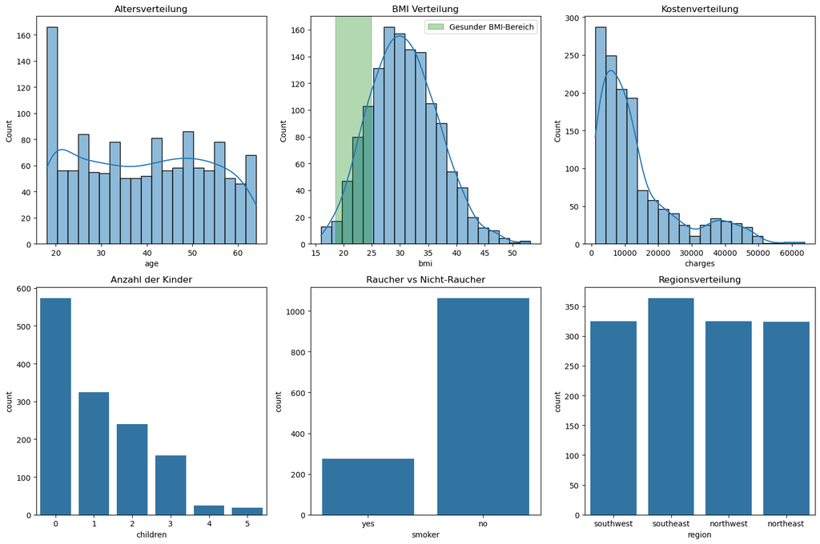

```python
# Plot distributions of numerical features
plt.figure(figsize=(15, 10))

# Age distribution
plt.subplot(2, 3, 1)
sns.histplot(df['age'], bins=20, kde=True)
plt.title('Altersverteilung')

# BMI distribution
plt.subplot(2, 3, 2)
sns.histplot(df['bmi'], bins=20, kde=True)
plt.title('BMI Verteilung')
# Bereich von 18,5 bis 24,9 in grün
plt.axvspan(18.5, 24.9, color='green', alpha=0.3, label='Gesunder BMI-Bereich')
plt.legend()

# Charges distribution
plt.subplot(2, 3, 3)
sns.histplot(df['charges'], bins=20, kde=True)
plt.title('Kostenverteilung')

# Number of children
plt.subplot(2, 3, 4)
sns.countplot(data=df, x='children')
plt.title('Anzahl der Kinder')

# Smoker vs Non-Smoker
plt.subplot(2, 3, 5)
sns.countplot(data=df, x='smoker')
plt.title('Raucher vs Nicht-Raucher')

# Region distribution
plt.subplot(2, 3, 6)
sns.countplot(data=df, x='region')
plt.title('Regionsverteilung')

plt.tight_layout()
plt.show()
```

```
Correlation Matrix:
               age       bmi  children   charges
age       1.000000  0.109272  0.042469  0.299008
bmi       0.109272  1.000000  0.012759  0.198341
children  0.042469  0.012759  1.000000  0.067998
charges   0.299008  0.198341  0.067998  1.000000
```

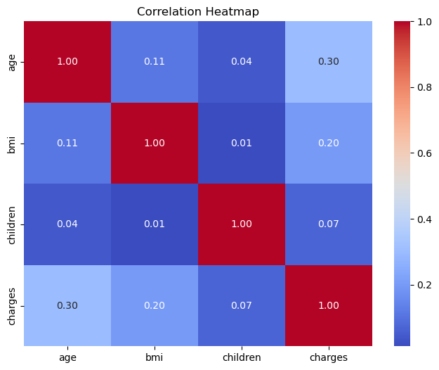

```python
# Correlation matrix
correlation_matrix = df.corr(numeric_only=True)
print("\nCorrelation Matrix:")
print(correlation_matrix)

# Heatmap for correlation
plt.figure(figsize=(8, 6))
sns.heatmap(correlation_matrix, annot=True, cmap='coolwarm', fmt='.2f')
plt.title('Correlation Heatmap')
plt.show()
```

### Features vs Kosten

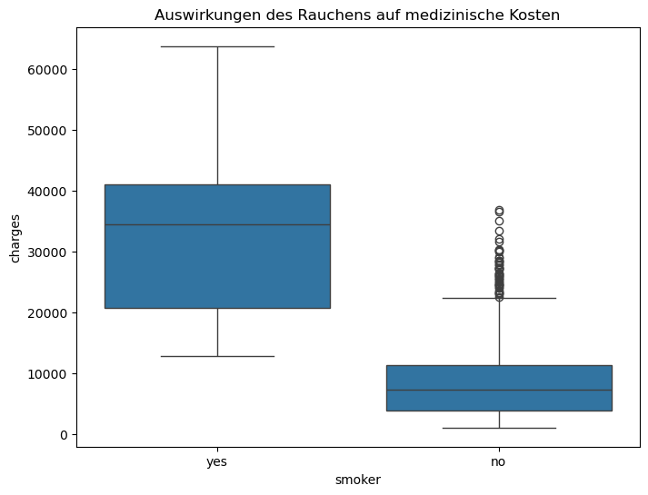

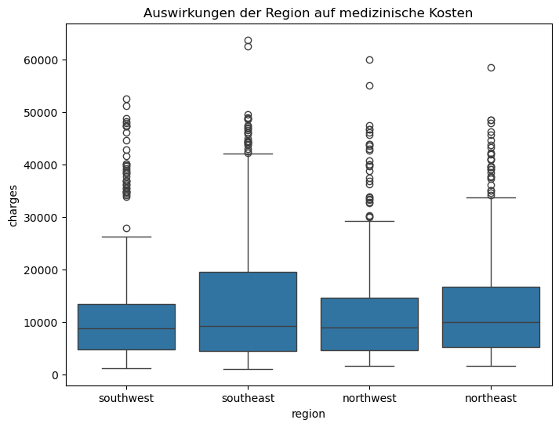

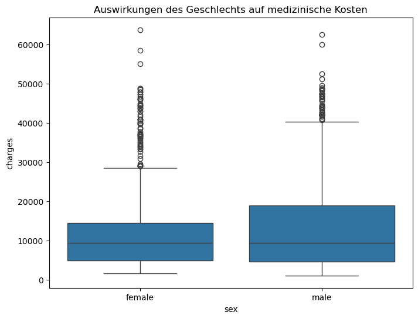

```python
# Impact of smoking on charges
plt.figure(figsize=(8, 6))
sns.boxplot(data=df, x='smoker', y='charges')
plt.title('Auswirkungen des Rauchens auf medizinische Kosten')
plt.show()

# Impact of region on charges
plt.figure(figsize=(8, 6))
sns.boxplot(data=df, x='region', y='charges')
plt.title('Auswirkungen der Region auf medizinische Kosten')
plt.show()

# Impact of sex on charges
plt.figure(figsize=(8, 6))
sns.boxplot(data=df, x='sex', y='charges')
plt.title('Auswirkungen des Geschlechts auf medizinische Kosten')
plt.show()
```

**Auswirkungen des Rauchens auf medizinische Kosten (Boxplot)** Raucher haben deutlich höhere medizinische Kosten als Nichtraucher. Die Verteilung zeigt, dass Raucher nicht nur höhere Durchschnittskosten haben, sondern auch eine größere Streuung.

**Auswirkungen der Region auf medizinische Kosten (Boxplot)** Die medizinischen Kosten variieren leicht je nach Region. Der Südosten scheint tendenziell höhere Kosten zu haben, aber die Unterschiede zwischen den Regionen sind nicht sehr ausgeprägt.

**Auswirkungen des Geschlechts auf medizinische Kosten (Boxplot)** Es gibt kaum Unterschiede in den medizinischen Kosten zwischen Männern und Frauen. Die Verteilung und der Median sind sehr ähnlich.

# 3) Preprocessing Steps

```python
# Machine Learning Models
# Encode categorical variables
label_encoders = {}
for col in ['sex', 'smoker', 'region']:
    le = LabelEncoder()
    df[col] = le.fit_transform(df[col])
    label_encoders[col] = le
```

```python
# Split Data into Training and Testing Sets
# Define features and target
X = df.drop(columns=['charges'])
y = df['charges']

# Split the data
X_train, X_test, y_train, y_test = train_test_split(X, y, test_size=0.2, random_state=42)

# Scale numerical features
scaler = StandardScaler()
X_train_scaled = scaler.fit_transform(X_train)
X_test_scaled = scaler.transform(X_test)
```

# 4) Build and Evaluate

```
Linear Regression Performance:
MSE: 33635210.431178436, R2 Score: 0.7833463107364537

Feature Importances from Linear Regression:
smoker      9557.143383
age         3616.108652
bmi         2028.308579
children     516.662566
sex           -9.392954
region      -302.387980
dtype: float64
```

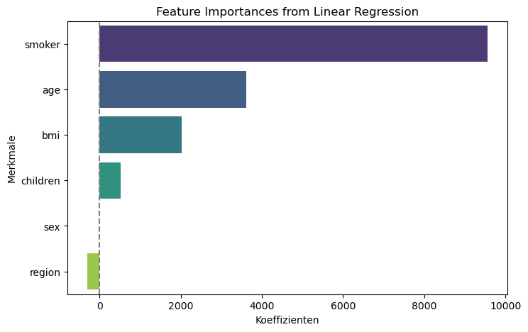

```python
# Train and Evaluate Linear Regression
# Train Linear Regression model
lr_model = LinearRegression()
lr_model.fit(X_train_scaled, y_train)
y_pred_lr = lr_model.predict(X_test_scaled)

# Evaluate Linear Regression model
mse_lr = mean_squared_error(y_test, y_pred_lr)
r2_lr = r2_score(y_test, y_pred_lr)
print("\nLinear Regression Performance:")
print(f"MSE: {mse_lr}, R2 Score: {r2_lr}")

# Feature importance from coefficients
feature_importances_lr = pd.Series(lr_model.coef_, index=X.columns)
print("\nFeature Importances from Linear Regression:")
print(feature_importances_lr.sort_values(ascending=False))

# Feature Importances sort values
sorted_importances = feature_importances_lr.sort_values(ascending=False)

# Visualization
plt.figure(figsize=(8, 5))
sns.barplot(x=sorted_importances.values, y=sorted_importances.index, palette='viridis')
plt.title('Feature Importances from Linear Regression')
plt.xlabel('Koeffizienten')
plt.ylabel('Merkmale')
plt.axvline(0, color='grey', linestyle='--')
plt.show()
```

```
Random Forest Performance:
MSE: 20897417.646036554, R2 Score: 0.8653939555883334

Feature Importances from Random Forest:
smoker      0.608618
bmi         0.216342
age         0.134502
children    0.020197
region      0.013904
sex         0.006436
dtype: float64
```

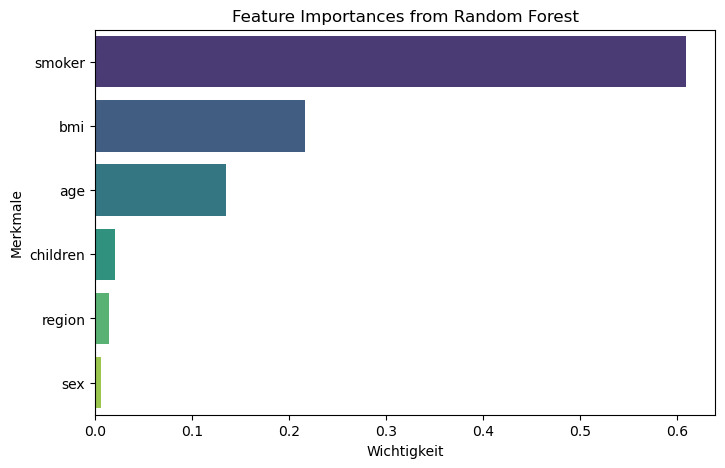

```python
# Train and Evaluate Random Forest Regressor
# Train Random Forest model
rf_model = RandomForestRegressor(random_state=42)
rf_model.fit(X_train_scaled, y_train)
y_pred_rf = rf_model.predict(X_test_scaled)

# Evaluate Random Forest model
mse_rf = mean_squared_error(y_test, y_pred_rf)
r2_rf = r2_score(y_test, y_pred_rf)
print("\nRandom Forest Performance:")
print(f"MSE: {mse_rf}, R2 Score: {r2_rf}")

# Feature importance from Random Forest
feature_importances_rf = pd.Series(rf_model.feature_importances_, index=X.columns)
print("\nFeature Importances from Random Forest:")
print(feature_importances_rf.sort_values(ascending=False))

# Feature Importances sort value
sorted_importances_rf = feature_importances_rf.sort_values(ascending=False)

# Visualization
plt.figure(figsize=(8, 5))
sns.barplot(x=sorted_importances_rf.values, y=sorted_importances_rf.index, palette='viridis')
plt.title('Feature Importances from Random Forest')
plt.xlabel('Wichtigkeit')
plt.ylabel('Merkmale')
plt.axvline(0, color='grey', linestyle='--')
plt.show()
```

# 5) Insights: high-risk individuals

```python
# Identify high-risk individuals (smokers with high BMI):
high_risk = df[(df['smoker'] == 1) & (df['bmi'] > 30)]
print("\nHochrisikopersonen (Raucher mit hohem BMI):):")
print(high_risk[['age', 'sex', 'bmi', 'smoker', 'charges']])
```

```
Hochrisikopersonen (Raucher mit hohem BMI):):
      age  sex     bmi  smoker      charges
14     27    1  42.130       1  39611.75770
19     30    1  35.300       1  36837.46700
23     34    0  31.920       1  37701.87680
29     31    1  36.300       1  38711.00000
30     22    1  35.600       1  35585.57600
...   ...  ...     ...     ...          ...
1300   45    1  30.360       1  62592.87309
1301   62    1  30.875       1  46718.16325
1308   25    0  30.200       1  33900.65300
1313   19    0  34.700       1  36397.57600
1323   42    0  40.370       1  43896.37630

[144 rows x 5 columns]
```

# 6) Maßnahmen zur Reduzierung medizinischer Kosten

### 1. Raucher als größte Kostenverursacher – Fokus auf Prävention und Raucherentwöhnung**

Raucher verursachen im Durchschnitt deutlich höhere medizinische Kosten als Nichtraucher. Präventionsprogramme zur Reduktion der Raucherquote könnten somit direkte Kosteneinsparungen bewirken.

**Empfohlene Maßnahmen:**

- Staatlich oder privat finanzierte Raucherentwöhnungsprogramme (z. B. Subventionierung von Nikotinersatztherapien).
- Aufklärungskampagnen zu den finanziellen und gesundheitlichen Folgen des Rauchens.
- Finanzielle Anreize für Nichtraucher in Krankenversicherungen, z. B. Prämienrabatte.

### 2. Alter als klarer Kostenindikator – Früherkennung und Gesundheitsförderung ausbauen

Die Analyse zeigt, dass die medizinischen Kosten mit dem Alter steigen, besonders bei Rauchern.

**Empfohlene Maßnahmen:**

- Förderung von Vorsorgeuntersuchungen für ältere Personen, um chronische Erkrankungen frühzeitig zu erkennen.
- Anpassung der Versicherungsprämien mit Altersgruppen-spezifischen Programmen zur Gesundheitsförderung.
- Investition in Technologien zur Fernüberwachung von Gesundheitsparametern für ältere Menschen, um Krankenhausaufenthalte zu reduzieren.

### 3. BMI und Kosten – Präventionsstrategien gegen Übergewicht etablieren

Ein hoher BMI korreliert mit steigenden medizinischen Kosten, insbesondere bei Rauchern.

**Empfohlene Maßnahmen:**

- Betriebliche Gesundheitsförderung, um Übergewicht vorzubeugen (z. B. Sportangebote, Ernährungsberatung).
- Unterstützung für gesunde Ernährung durch staatliche Subventionen für gesunde Lebensmittel.
- Versicherungsanreize für gesunde Lebensführung, ähnlich wie bei Nichtrauchern.